# Wk 3 Homework

Idil Karen Sahin

## 1- SIR model with demography

### [Q1] Plot %I vs time for both models and compare. What is the main difference and why? (1pt)

```r
library(deSolve)


SIR=function(t,state,parameters){
  with(as.list(c(state,parameters)),{

    # rate of change
    dS=-beta*S*I/N;
    dI=beta*S*I/N-gamma*I;

    # NOTE: EQUATION FOR CUMULATIVE INCIDENCE IS SHOWN BELOW
    # dcumInic=beta*S*I/N;

    # return the rate of change
    list(c(dS,dI))
  }) # end with(as.list...)
}

## SIR model with demography
SIRdem=function(t,state,parameters){
  with(as.list(c(state,parameters)),{

    # rate of change
    dS=mu*N-beta*S*I/N-mu*S;
    dI=beta*S*I/N-gamma*I-mu*I;

    # return the rate of change
    list(c(dS,dI))
  }) # end with(as.list...)
}


N=1e5; I0=20; S0=0.2*N;
state=c(S=S0,I=I0);

beta=520/365; gamma=1/7; mu=1/(70*365);
parameters.SIR= c(beta, gamma)
parameters.SIRdem= c(beta, gamma, mu)

times=seq(0,365*100,by=1);

sim.SIR=ode(y=state,times=times,func=SIR,parms=parameters.SIR);
s.SIR=sim.SIR[,'S']/N  # %S
i.SIR=sim.SIR[,'I']/N  # %I

# for the SIRdem model
sim.SIRdem=ode(y=state,times=times,func=SIRdem,parms=parameters.SIRdem);
s.SIRdem=sim.SIRdem[,'S']/N
i.SIRdem=sim.SIRdem[,'I']/N

# plot results: S & I vs time
par(mfrow=c(2,2),mar=c(3,3,1,1),mgp=c(1.8,.5,0))
plot(sim.SIRdem[,'time'],s.SIRdem,ylab='% S.Dem',xlab='Time (day)', type='l',col='blue',lwd=1)
plot(sim.SIRdem[,'time'],i.SIRdem,ylab='% I.Dem',xlab='Time (day)', type='l',col='red',lwd=1)
```

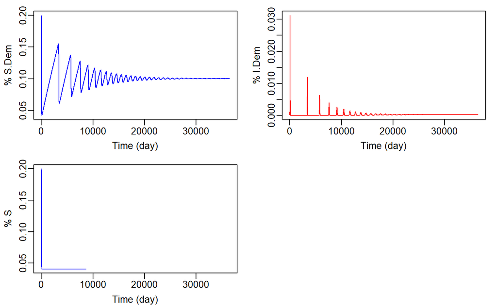

```r
plot(sim.SIR[,'time'],s.SIR,ylab='% S',xlab='Time (day)', type='l',col='blue',lwd=1)
plot(sim.SIR[,'time'],i.SIR,ylab='% I',xlab='Time (day)', type='l',col='red',lwd=1)
```

```r
NA
NA
```

Here we can observe the first and last 10 years:

```r
## to see just the *first* few years:
# set the limit for x-axis using xlim=c(xmin,xmax)

par(mfrow=c(2,2),mar=c(3,3,1,1),mgp=c(1.8,.5,0))

plot(sim.SIRdem[,'time'],s.SIRdem,ylab='% S',xlab='Time',xlim=c(1,365*10),
     type='l',col='blue')
plot(sim.SIRdem[,'time'],i.SIRdem,ylab='% I',xlab='Time',xlim=c(1,365*10),
     type='l',col='red')
```

```r
plot(sim.SIR[,'time'],s.SIR,ylab='% S',xlab='Time',xlim=c(1,365*10),
     type='l',col='blue')
plot(sim.SIR[,'time'],i.SIR,ylab='% I',xlab='Time',xlim=c(1,365*10),
     type='l',col='red')
```

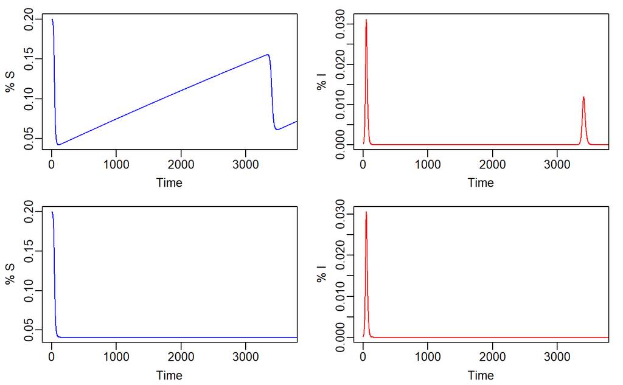

```r
par(mfrow=c(2,2),mar=c(3,3,1,1),mgp=c(1.8,.5,0))
```

```r
plot(sim.SIRdem[,'time'],s.SIRdem,ylab='% S',xlab='Time',xlim=c(365*90 + 1,365*100),
     type='l',col='blue')
plot(sim.SIRdem[,'time'],i.SIRdem,ylab='% I',xlab='Time',xlim=c(365*90 + 1, 365*100),
     type='l',col='red')
```

[figure not shown]

```r
plot(sim.SIR[,'time'],s.SIR,ylab='% S',xlab='Time',xlim=c(365*90 + 1, 365*100),
     type='l',col='blue')
plot(sim.SIR[,'time'],i.SIR,ylab='% I',xlab='Time',xlim=c(365*90 + 1, 365*100),
     type='l',col='red')
```

We observe the main difference between models is that in SIR epidemic takeoff happens only once (single continuous decrease in S and a bell curve in I); whereas in the SIRdem, the values for S and I fluctuate and eventually reach equilibrium. This is due to the births and deaths; new members(susceptibles) are continuously added to the model and members of each category die, leaving the model.

### [Q2]. What are the %S (S/N), and %I (I/N) at the end of the simulation? How are these values (i.e. S/N, and I/N at equilibrium)compared to those computed by the formula we derived in the class? (0.5pt)

```r
tail(na.omit(s.SIR),n=1)
```

```
[1] 0.04080017
```

```r
round(tail(na.omit(i.SIR),n=1))
```

```
[1] 0
```

As we found mathematically in class, I=0 at the end of the epidemic according to the SIR model without demography.

```r
tail(s.SIRdem,n=1) # numerical result, S
```

```
[1] 0.1001976
```

```r
dR_0 <- beta/(gamma+ mu)
1/dR_0 # analytical result, S
```

```
[1] 0.1003022
```

```r
tail(na.omit(i.SIRdem),n=1) # numerical result, I
```

```
[1] 0.0002458337
```

```r
mu/beta*(dR_0-1) # analytical result, I
```

```
[1] 0.000246425
```

For SIRdem, we observe the numerical results match with the analytical results we derived in class.

## 2- SIS Model

### [Q3]. Complete the SIS model - include your code for the SIS model in your report(0.5 pt)

```r
SIS=function(t,state,parameters){
  with(as.list(c(state,parameters)),{
    # rate of change

    # EQUATIONS for the SIS:
    dS= -beta*S*I/N + gamma*I;
    dI= beta*S*I/N - gamma*I;
    # return the rate of change
    list(c(dS,dI))
  })
}
```

### [Q4]. Run the SIS model using the following initial conditions: N=1e5; I0=10; S0=N-I0; beta=.5; gamma=.3; times=0:100. Plot S vs time and I vs time. (0.5pt)

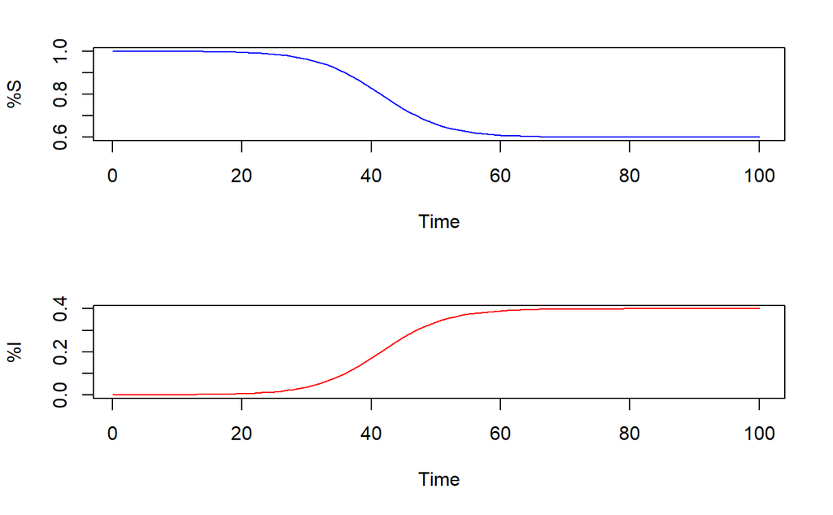

```r
N=1e5; I0=10; S0=N-I0;
state=c(S=S0,I=I0);
parameters=c(beta=.5,gamma=.3);

times=seq(0,100,by=1);
sim=ode(y=state,times=times,func=SIS,parms=parameters);
s=sim[,'S']/N
i=sim[,'I']/N

par(mfrow=c(2,1))
plot(sim[,'time'],s,ylab='%S',xlab='Time',xlim=c(1, 100),
     type='l',col='blue')
plot(sim[,'time'], i,ylab='%I',xlab='Time',xlim=c(1, 100),
     type='l',col='red')
```

### [Q5]. What are S/N and I/N at equilibrium? How are these values compared to results from the formula derived from the model (I*/N=1-1/R0 and S*/N=1/R0)? (0.5pt)

```r
tail(s, n=1) # S
```

```
[1] 0.6000033
```

```r
beta=.5;gamma=.3;
R_0 = beta/gamma
1/R_0
```

```
[1] 0.6
```

```r
tail(i, n=1) # I
```

```
[1] 0.3999967
```

```r
1- 1/R_0
```

```
[1] 0.4
```

We observe the numerical results match with the derived formula.

## 3- SEIR Model

### [Q6]. Code up an SEIR model based on the equations above [provide your code for the SEIR model in your report]. (1pt)

```r
SIR=function(t,state,parameters){
  with(as.list(c(state,parameters)),{
    # rate of change
    dS=-beta*S*I/N;
    dI=beta*S*I/N-gamma*I;

    # cumulative incidence
    dcumInci=beta*S*I/N;

    # return the rate of change
    list(c(dS,dI,dcumInci))
  })
}


SEIR=function(t,state,parameters){
  with(as.list(c(state,parameters)),{
    # rate of change
    dS= -beta*S*I/N;
    dE= + beta*S*I/N - alpha*E;
    dI= + alpha*E -gamma*I;

    # return the rate of change
    dcumInci=beta*S*I/N;


    # RETURN ALL STATE VARIABLES:
    list(c(dS,dE,dI, dcumInci))
  })
}
```

### [Q7]. Compare S, I, Incidence, over time computed by the 2 models. What are the differences between the two simulations? (1pt)

```r
##PARMS/INI CONDS:
times=0:100
N=1e5; E0=10; I0=0; S0=N-E0-I0;
stateSEIR=c(S=S0,E=E0,I=I0, cumInci=0);
paramSEIR=c(beta=.6,alpha=1/1.5,gamma=1/3);
simSEIR=ode(y=stateSEIR,times=times,func=SEIR,parms=paramSEIR) # run SEIR

stateSIR=c(S=S0,I=E0, cumInci=E0);
paramSIR=c(beta=.4,gamma=1/4.5);  # to keep the same serial interval and R0
simSIR=ode(y=stateSIR,times=times,func=SIR,parms=paramSIR) # run SIR

s_SEIR=simSEIR[,'S']/N; i_SEIR=simSEIR[,'I']/N; e_SEIR=simSEIR[,'E']/N;

s_SIR=simSIR[,'S']/N; i_SIR=simSIR[,'I']/N;


newi_SEIR=simSEIR[-1,'cumInci']/N-simSEIR[-length(times),'cumInci']/N; # new cases
newi_SIR=simSIR[-1,'cumInci']/N-simSIR[-length(times),'cumInci']/N; # new cases


#Susceptible
par(mfrow=c(3,1),cex=.8,mgp=c(1.8,.5,0),mar=c(3,3,1,1))
plot(times,s_SEIR,ylim=c(0,1),
     ylab='% S',xlab='Time', type='l',col='blue', main = "S")
lines(times,s_SIR,col='blue',lty=2)
```

```r
#Infectious
ymax=max(i_SEIR,i_SIR)*1.05
plot(times,i_SEIR,ylim=c(0,ymax),col='red',ylab='% I',xlab='Time', type = "l", main= "I")
lines(times,i_SIR,col='red',lty=2)
```

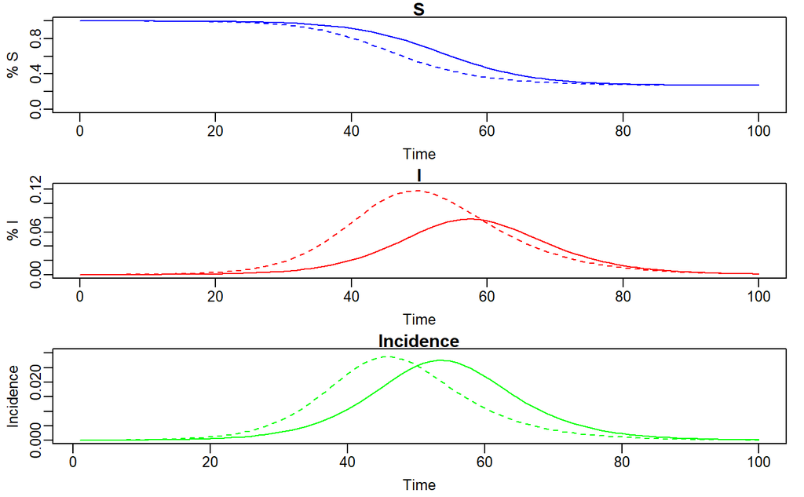

```r
# Incidence
ymax=max(newi_SEIR,newi_SIR)*1.05
plot(newi_SEIR,ylim=c(0,ymax),col='green',ylab='Incidence',xlab='Time', type='l', main = "Incidence")
lines(newi_SIR,col='green',lty=2)
```

```r
# Recovered patients
1- tail(s_SEIR, n=1) - tail(e_SEIR, n=1) - tail(i_SEIR, n=1) #SEIR
```

```
[1] 0.7299978
```

```r
1- tail(i_SIR, n=1) - tail(s_SIR, n=1) #SIR
```

```
[1] 0.730552
```

- SEIR has slower growth rate,as we see clearly in graph 3, since susceptibles pass through the latent period and resulting in a delayed response.
- The final S/N and incidence values are the same.